# STAT_6311_Exam_2

## STAT 6311 Exam 2 (Fall 2021)

## Last Updated: 11/30/2021

$$\newcommand{\C}{\mathbb{C}} \newcommand{\R}{\mathbb{R}} \newcommand{\Z}{\mathbb{Z}} \newcommand{\Q}{\mathbb{Q}} \newcommand{\F}{\mathbb{F}}$$

**1.** Suppose that $X$ has the following density function:

$$f(x) = \begin{cases} \frac{1}{4}e^{-\frac{x}{4}}, & \mbox{ for } x \geq 0 \\ 0, & \mbox{ otherwise } \end{cases} $$

**a.)** Find the CDF of $X$.

*SOLUTION:*

> **Definition 4.2** A random variable $Y$ with distribution function $F(y)$ is said to be *continuous* if $F(y)$ is continuous, for $-\infty < y < \infty$.

$$\int \frac{1}{4}e^{\frac{-t}{4}} dt = \frac{1}{4} \int e^{\frac{-t}{4}} = -4*\frac{1}{4} \int e^{u} du = -\int e^{u} du = -e^{\frac{-t}{4}}|_{0}^{x} = - e^{\frac{-x}{4}} + e^{\frac{0}{4}} = -e^{\frac{-x}{4}} = F(x)$$$$\text{U-substitutionu: } u=-\frac{t}{4} \to du=-\frac{1}{4} dt \to -4 du = dt$$$$F(x) = \begin{cases} -e^{-\frac{x}{4}}, & \mbox{ for } x \geq 0 \\ 0, & \mbox{ otherwise } \end{cases} $$

**PROOF:**  
Suppose $F$ is the CDF and is a continuous and differentiable function on $\R$, then $f$ is its derivative for $\forall x \in \R$ and is thus its PDF by Definition 4.3. Therefore by the first part of Fundamental Theorem of Calculus, $F$ is defined as,

$$F(x) = \int_{-\infty}^{x} f(t) dt.$$

If one is to evaluate the integrand over the bounds, one would get the following:

$$F(x) = \int_{-\infty}^{x} f(t) dt = F(t) |_{-\infty}^{x} = F(x) - F(-\infty) = F(x) - 0 = F(x).$$

As found in Theorem 4.1, $F(-\infty)=0$, this is because as $x$ tends to $-\infty$, $F(x)$ tends towards 0.

**b.)** Use your answer in (a) to easily find $p(x \geq 4.5)$.

*SOLUTION:*

It is too easy to misconstrue this question. As you mention that your answer from *(a)* could be used to easily find the probability mass found in interval of $[4.5,\infty)$, it is infer that you wanted the measurement to be the cumulative distribution function, and not the probability density function.

$$p(x \geq 4.5) = \int_{4.5}^{\infty} -\frac{1}{4} e^{\frac{-x}{4}} dx = \frac{1}{4} \int_{4.5}^{\infty} e^{-\frac{x}{4}} dx = -4*\frac{1}{4} \int_{4.5}^{\infty} e^{u} du = -\int_{4.5}^{\infty} e^{u} du $$$$=-e^{-\frac{-x}{4}} |_{4.5}^{\infty} = -e^{-\frac{\infty}{4}}+e^{-\frac{4.5}{4}} = 0 + e^{-\frac{4.5}{4}}= e^{-\frac{4.5}{4}}$$

One would formally integrate the integrand (probability density function) to attain the antiderivative (cumulative probability distribution), then evaluate the antiderivative at the end points of the interval $[4.5,\infty)$ as found in the second part of the Fundamental Theorem of Calculus.

**c.)** Find the $25^{\text{th}}$ percentile of $X$.

*SOLUTION:*

$$\int_{0}^{x} \frac{1}{4} e^{-\frac{t}{4}} \ dt = \frac{1}{4} \int_{0}^{x} e^{-\frac{t}{4}} \ dt = - \int_{0}^{x} e^{u} \ du = - [e^{-\frac{t}{4}}] |_{0}^{x} = -1 [1-e^{-\frac{x}{4}}]=0.25$$$$\text{U-substitutionu: } u=-\frac{t}{4} \to du=-\frac{1}{4} dt \to -4 du = dt$$$$\to -1 [1-e^{-\frac{x}{4}}]=0.25 \to -1 + e^{-\frac{x}{4}} = 0.25 \to 1.25 = e^{-\frac{x}{4}}$$$$\to \ln{1.25} = \ln{e^{-\frac{x}{4}}} \to \ln{1.25} = -\frac{x}{4} \to x = -4 \ln{1.25}$$

**2.** Heights of children at an elementary school are normally distributed with $\mu = 42$ and $\sigma = 4$. Approximately what proportion of students have a height of $2$ or more inches above the height that cuts off the lowest $30\%$?

*SOLUTION:*

We have a normally distributed random variable $X$, with $\mu = 42$ and $\sigma = 4$. We need to determine the probability from $x_0$, which represents the probability that a student fall into the category of 2 inches or more from the lowest $30\%$. But lets first graph out this normal random variable on a cartesian graph.

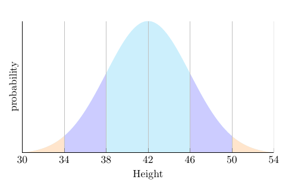

Now lets standardizes this non-standard normal random variable to a standard normal distribution.

$$38 \leq x \leq 46 \to \frac{38-42}{4} \leq \frac{x-\mu}{\sigma} \leq \frac{46-42}{4} \to -1 \leq z \leq 1$$$$34 \leq x \leq 50 \to \frac{34-42}{4} \leq \frac{x-\mu}{\sigma} \leq \frac{50-42}{4} \to -2 \leq z \leq 2$$$$30 \leq x \leq 54 \to \frac{30-42}{4} \leq \frac{x-\mu}{\sigma} \leq \frac{54-42}{4} \to -3 \leq z \leq 3$$

[figure not shown]

Now we are able to calculate the cutoff height that represents the lowest $30\%$ of this distribution. Taking an approximate z-value of a z-table, the lowest 0.30 is between -0.52 and -0.53, we chose -0.53 here.

$$-0.53 = \frac{x-42}{4} \to -2.12 = x - 42 \to x = 39.88$$

We can calculate $x_0$, $x0=x+2=41.88$, and it z-value, $z=\frac{41.88-42}{4}=-0.03$. Let regraph of the non-standardized $X$ on a new cartesian graph with $x0$ marked.

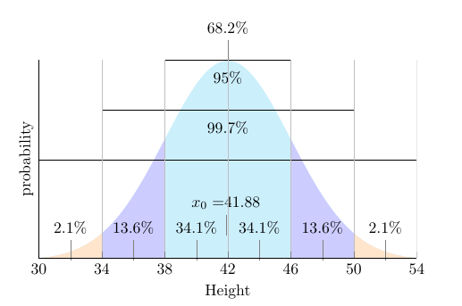

$$P(x \geq x_0 = 41.88) = P(z \geq -0.03) = (P(z \geq 0)-P(z \geq -0.03))+P(z \geq 0)$$$$=(0.5000-0.4880)+0.5000=0.0120+0.5000=0.5120$$

Hence $P(x \geq x_0=41.88) = 0.5120$. $\square$

**3.** (These four problems should not require integration - you should (be able to) recognize the PDFs and MFGs.)

**a.)** What is the value of $c$ in the PDF:

*SOLUTION:*

$$f(x) = \begin{cases} cx^{2}(1-x)^{4}, & \mbox{ for } 0 \leq x \leq 1 \\ 0, & \mbox{ otherwise } \end{cases} $$

We were given Beta PDF with $\alpha=3$ and $\beta=5$, and by definition this is a type of Beta distributed random.

Beta PDF: $$f(x)=\frac{x^{\alpha-1}(1-x)^{\beta-1}}{B(\alpha,\beta)}$$

$$c=\frac{1}{B(\alpha,\beta)}=\frac{1}{B(3,5)}=\frac{1}{\frac{\Gamma(3)\Gamma(5)}{\Gamma(3+5)}}= \frac{(8-1)!}{(3-1)!(5-1)!} = \frac{7!}{2!4!}=105$$$$f(x) = \begin{cases} 105x^{2}(1-x)^{4}, & \mbox{ for } 0 \leq x \leq 1 \\ 0, & \mbox{ otherwise } \end{cases} $$

**b.)** What is the value of $c$ in the PDF:

*SOLUTION:*

$$f(x) = \begin{cases} cx^{5}e^{-\frac{x}{2}}, & \mbox{ for } x \geq 0 \\ 0, & \mbox{ otherwise } \end{cases} $$

We were given Gamma PDF with $\alpha=6$ and $\beta=2$, and by definition this is a type of Beta distributed random.

Gamma PDF: $$f(x)=\frac{x^{\alpha-1}e^{-\frac{x}{\beta}}}{\beta^{\alpha}\Gamma(\alpha)}$$

$$c=\frac{1}{\beta^{\alpha}\Gamma(\alpha)}=\frac{1}{2^{6}(6-1)!}=\frac{1}{2^{6}5!}=\frac{1}{64*120}=\frac{1}{7680}$$$$f(x) = \begin{cases} \frac{1}{7680}x^{5}e^{-\frac{x}{2}}, & \mbox{ for } x \geq 0 \\ 0, & \mbox{ otherwise } \end{cases} $$

**c.)** Suppose that the MGF of $X$ is given by $m(t)=e^{4t+\frac{9t^{2}}{2}}$. What is $P(X \geq 7)$?

*SOLUTION:*

We were given a normal MGF: $m(t)=e^{4t+\frac{9t^{2}}{2}}$, with mean, $\mu=4$, variance, $\sigma^{2} = 9$, and standard deviation, $\sigma = 3$.

$$z=\frac{x-\mu}{\sigma}=\frac{7-4}{3}=\frac{3}{3}=1 \to P(x \geq 7) = P(z \geq 1) = 0.1587 \to P(x \geq 7) = 0.1587$$

**d.)** Suppose that the MGF of $X$ is given by $m(t)=(1-4t)^{-3}$. What is the standard deviation of $X$?

*SOLUTION:*

We were given a Gamma MFG: $m(t)=(1-\beta t)^{-\alpha}$ with $\alpha = 3$ and $\beta = 4$.

$$\text{Var}(x)=\alpha \beta^{2} = (3)(4)^{2}=48 \to \text{Var}(x)=\sigma^{2}$$$$\sigma = \sqrt{\text{Var}(x)}=\sqrt{\sigma^{2}}=\sqrt{48} \to \sigma = \sqrt{48}$$

**4.** The joint density function of $X$ and $Y$ is

$$f(x,y) = \begin{cases} \frac{5}{81}x^{2}y, & \mbox{ for } 0 < x < y < 3 \\ 0, & \mbox{ otherwise } \end{cases}$$

Find the marginal density function of $Y$.

*SOLUTION:*

$$f_{Y} = \int_{0}^{y} x^{2}y \ dx = \frac{5}{81} \int_{0}^{y} x^{2}y \ dx = \frac{5y}{81}[\frac{x^{3}}{3}] |_{0}^{y} = \frac{5y^{4}}{243}$$$$f_{Y} = \begin{cases} \frac{5y^{4}}{243}, & \mbox{ for } 0 < x < y < 3 \\ 0, & \mbox{ otherwise } \end{cases}$$

**5.** The joint density function of $X$ and $Y$ is

$$f_{XY}(x,y) = \begin{cases} xe^{-x(y+1)}, & \mbox{ for } x > 0, y > 0 \\ 0, & \mbox{ otherwise } \end{cases}$$

Find the conditional density function of $Y$, given that $X=2$.

*SOLUTION:*

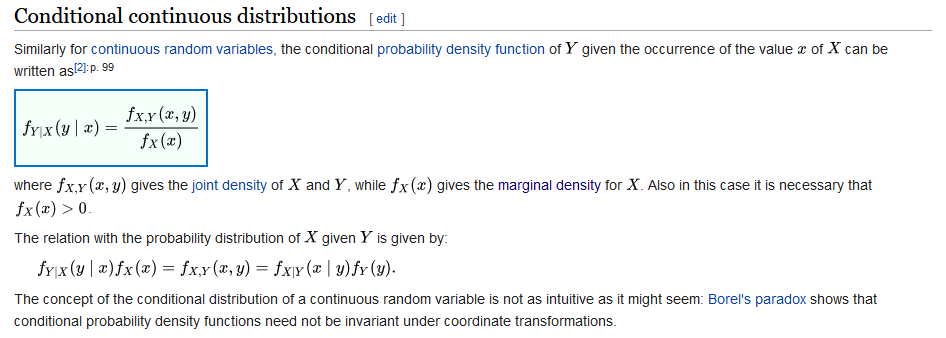

Wikipedia: [Conditional Probability Distribution](https://en.wikipedia.org/wiki/Conditional_probability_distribution)

$$f_{X} = \int_{0}^{x} x e^{-x(y+1)} \ dy = \int_{0}^{x} x e^{-xy} e^{-x} \ dy = x e^{-x} \int_{0}^{x} e^{-xy} \ dy$$$$\text{U-substitutionu: } u=-xy \to du=-x dy \to -\frac{du}{x} = dy$$$$= -\frac{x}{x} e^{-x} \int_{0}^{x} e^{u} \ du = - e^{-x} \int_{0}^{x} e^{u} \ du = - e^{-x} [e^{-xy}] |_{0}^{x} = -e^{-x}[e^{-x^{2}}- 1]$$$$f_{Y|X}(y|x=2) = \frac{f_{XY}(x,y)}{f_{X}(x)} = \frac{2e^{-2(y+1)}}{-e^{-2}[e^{-4}-1]}$$

**6.** Let $X$ and $Y$ be independent and identically distributed random variables with CDF of $X$ given by $f(x) = \begin{cases} 1-e^{-2x}, & \mbox{ for } x > 0 \\ 0, & \mbox{ otherwise } \end{cases}$. Since $X$ and $Y$ are identically distributed, this means that the CDF of $Y$ is given by $f(y) = \begin{cases} 1-e^{-2y}, & \mbox{ for } 0 < y > 0 \\ 0, & \mbox{ otherwise } \end{cases}$. Find $P(3X + 2Y > 5)$. (Hint: first find the joint density of $X$ and $Y$.)

*SOLUTION:*

$$f(x)=\frac{d}{dx}(-e^{-2x}) = 2e^{-2x} \; \text{ and } \; f(y)=\frac{d}{dy}(-e^{-2y})=2e^{-2y}$$$$f(x,y)=f(x)f(y)=(2e^{-2x})(2e^{-2y})=4e^{-2(x+y)} \to f(x,y) = 4e^{-2(x+y)}$$

Inequality: $3X + 2Y > 5$

[figure not shown]

As 3D plot of $3X + 2Y > 5$ and $f(x,y) = 4e^{-2(x+y)}$

[figure not shown]

$$P(3X + 2Y > 5)= \int_{0}^{\frac{5}{3}} \int_{\frac{5}{2}-\frac{3x}{2}}^{\infty} \int_{0}^{4e^{-2(x+y)}} 1 \ dz dy dx + \int_{5/3}^{\infty} \int_{0}^{\infty} \int_{0}^{4e^{-2(x+y)}} 1 \ dz dy dx$$

$$= \int_{0}^{\frac{5}{3}} \int_{\frac{5}{2}-\frac{3x}{2}}^{\infty} z |_{0}^{4e^{-2(x+y)}} \ dy dx + \int_{5/3}^{\infty} \int_{0}^{\infty} z |_{0}^{4e^{-2(x+y)}} \ dy dx = \int_{0}^{\frac{5}{3}} \int_{\frac{5}{2}-\frac{3x}{2}}^{\infty} (4e^{-2(x+y)}-0) \ dy dx + \int_{5/3}^{\infty} \int_{0}^{\infty} (4e^{-2(x+y)}-0) \ dy dx$$$$= \int_{0}^{\frac{5}{3}} \int_{\frac{5}{2}-\frac{3x}{2}}^{\infty} 4e^{-2(x+y)} \ dy dx + \int_{5/3}^{\infty} \int_{0}^{\infty} 4e^{-2(x+y)} \ dy dx = 4e^{-2x} \int_{0}^{\frac{5}{3}} \int_{\frac{5}{2}-\frac{3x}{2}}^{\infty} e^{-2y} \ dy dx + 4e^{-2x} \int_{5/3}^{\infty} \int_{0}^{\infty} e^{-2y} \ dy dx $$$$= -2e^{-2x} \int_{0}^{\frac{5}{3}} \int_{\frac{5}{2}-\frac{3x}{2}}^{\infty} e^{u} \ du dx - 2e^{-2x} \int_{5/3}^{\infty} \int_{0}^{\infty} e^{u} \ du dx = -2e^{-2x} \int_{0}^{\frac{5}{3}} e^{-2y} |_{\frac{5}{2}-\frac{3x}{2}}^{\infty}\ dx - 2e^{-2x} \int_{\frac{5}{3}}^{\infty} e^{-2y} |_{0}^{\infty}\ dx $$$$= -2e^{-2x} \int_{0}^{\frac{5}{3}} (0-e^{-2(\frac{5}{2}-\frac{3x}{2})}) \ dx - 2e^{-2x} \int_{\frac{5}{3}}^{\infty} (0-1) \ dx = 2e^{-2x} \int_{0}^{\frac{5}{3}} e^{-5+3x} \ dx + 2e^{-2x} \int_{\frac{5}{3}}^{\infty} 1 \ dx$$$$ = 2e^{-5} \int_{0}^{\frac{5}{3}} e^{x} \ dx + 2 \int_{\frac{5}{3}}^{\infty} e^{-2x} \ dx = 2e^{-5} \int_{0}^{\frac{5}{3}} e^{u} du - \int_{\frac{5}{3}}^{\infty} e^{u} \ du = 2e^{-5} [ e^{x} ]_{0}^{\frac{5}{3}} - [e^{-2x}]_{\frac{5}{3}}^{\infty}$$$$=2e^{-5} [ e^{\frac{5}{3}} - 1] -1 [0 - e^{-\frac{10}{3}}]=2e^{5} [ e^{\frac{5}{3}} - 1]+e^{-\frac{10}{3}} \approx 0.09355 \to P(3X + 2Y > 5) \approx 0.09355 \; \square$$

**7.** Let $X$ be a random variable (modeling lifetime Battery Type A, in weeks) with an exponential distribution with $\lambda = \frac{1}{3}$. Let $Y$ be a random variable (modeling lifetimes of Battery Type B, in weeks) with an exponential distribution with parameter $\lambda = \frac{1}{2}$. Furthermore, let $X$ and $Y$ be independent.

**a.)** What is the joint pdf of $X$ and $Y$? (Be sure to include the domains.)

*SOLUTION:*

Exponential PDF: $f(x)=\frac{1}{\beta}e^{-\frac{y}{\beta}}$, $\; 0 \leq y \leq \infty$

$$f(x)=\frac{1}{3}e^{-\frac{x}{3}} \text{ and } f(y)=\frac{1}{2}e^{-\frac{y}{2}}$$$$f(x,y)=f(x)f(y)=(\frac{1}{3}e^{-\frac{x}{3}})(f(y)=\frac{1}{2}e^{-\frac{y}{2}})=\frac{1}{6}e^{-\frac{x}{3}-\frac{y}{2}}$$$$f(x,y) = \begin{cases} \frac{1}{6}e^{-\frac{x}{3}-\frac{y}{2}}, & \mbox{ for } 0 \leq x \leq \infty, 0 \leq y \leq \infty \\ 0, & \mbox{ otherwise } \end{cases}$$

**b.)** What is the probability that both types of batteries have lifetimes that exceed 2.5 weeks?

*SOLUTION:*

$$P(x \geq 2.5, y \geq 2.5) = \int_{2.5}^{\infty} \int_{2.5}^{\infty} \frac{1}{6}e^{-\frac{x}{3}-\frac{y}{2}} \ dydx = \frac{1}{6}e^{-\frac{x}{3}} \int_{2.5}^{\infty} \int_{2.5}^{\infty} e^{-\frac{y}{2}} \ dydx$$$$\text{ U-Substitution: } u = -\frac{y}{2} \to \frac{d}{dy}(-\frac{y}{2})= -\frac{1}{2} \to du = -\frac{1}{2} dy \to -2 du = dy$$$$-\frac{1}{3}e^{-\frac{x}{3}} \int_{2.5}^{\infty} \int_{2.5}^{\infty} e^{u} \ dudx = -\frac{1}{3} e^{-\frac{x}{3}} \int_{2.5}^{\infty} e^{-\frac{y}{2}} |_{2.5}^{\infty} dx = -\frac{1}{3} e^{-\frac{x}{3}} \int_{2.5}^{\infty} (0 - e^{-\frac{2.5}{2}}) \ dx = \frac{1}{3} e^{-\frac{2.5}{2}} \int_{2.5}^{\infty} e^{-\frac{x}{3}} \ dx$$$$\text{ U-Substitution: } u = -\frac{x}{3} \to \frac{d}{dx}(-\frac{x}{3})= -\frac{1}{3} \to du = -\frac{1}{3} dx \to -3 du = dx$$$$= -e^{-\frac{2.5}{2}} \int_{2.5}^{\infty} e^{u} \ du = -e^{-\frac{2.5}{2}} [e^{-\frac{x}{3}}]_{2.5}^{\infty} = -e^{-\frac{2.5}{2}}[0-e^{-\frac{2.5}{3}}]=e^{-\frac{2.5}{2}}e^{-\frac{2.5}{3}}=e^{-\frac{25}{12}} \approx 0.1245$$

**8.** Let $X$ and $Y$ be random variables with joint pdf given by:

$$f(x,y) = \begin{cases} c(x+y), & \mbox{ for } 0 < x < 2, 0 < y < 2 \\ 0, & \mbox{ otherwise } \end{cases}$$

**a.)** Find the value of the constant $c$ so that this PDF (becomes) a legitimate joint pdf.

*SOLUTION:*

$$P(0 < x < 2, 0 < y < 2) = \int_{0}^{2} \int_{0}^{2} c(x+y) \ dydx = c \int_{0}^{2} \int_{0}^{2} x + y \ dydx = c \int_{0}^{2} xy + \frac{y^{2}}{2} |_{0}^{2} \ dx $$$$= c \int_{0}^{2} [(2x+2)-(0-0)] \ dx = c \int_{0}^{2} 2x+2 \ dx = c[x^{2}+2x] |_{0}^{2} = c [(4+4)-(0+0)]=8c=1$$$$8c=1 \to c=\frac{1}{8}$$$$f(x,y) = \begin{cases} \frac{1}{8}(x+y), & \mbox{ for } 0 < x < 2, 0 < y < 2 \\ 0, & \mbox{ otherwise } \end{cases}$$

**b.)** Find $P(Y>2X)$. (In your solution, clearly draw the region of integration.)

*SOLUTION:*

[figure not shown]

$$P(Y \geq 2X) = \int_{0}^{2} \int_{2x}^{2} \frac{1}{8}(x+y) \ dydx = \frac{1}{8} \int_{2x}^{2} [xy+\frac{y^{2}}{2}] |_{0}^{2} \ dx = \frac{1}{8} \int_{0}^{2} [ (2x+2)-(2x^{2}-2x^{2})] \ dx$$$$= \frac{1}{8} \int_{0}^{2} \int_{0}^{2} 2x + 2 - 2x^{2} - 2x^{2} \ dx = \frac{1}{8} [x^{2} + 2x - \frac{2}{3}x^{3} - \frac{2}{3}x^{3}] |_{0}^{2}= \frac{1}{8}[(\frac{8}{3})-(0)]=\frac{1}{3} \to P(Y \geq 2X) = \frac{1}{3}$$

**c.)** Find the marginal pdf of $X$ and the marginal pdf of $Y$.

*SOLUTION:*

[figure not shown]

Not sure why there is a obession definite integration, when indefinite integration would service the same purpose.

**PROOF:**  
Suppose there is a continuous and differentiable function $F$ over a half-open domain, D=[a,b] x [c,d], which is called the Joint CDF of random variables $X$ and $Y$. Taking the partial derivative of $F$ in respect to $X$, gives,

$$\frac{\partial}{\partial X} (F) = \frac{\partial F}{\partial X} = F_{X}$$

.

When the partial derivative of $F_{X}$ in respective of $Y$ is taken, then we get,

$$\frac{\partial}{\partial Y} (F_{X}) = \frac{\partial F_{X}}{\partial Y} = F_{XY}$$

,

which by the Theorem of Marginal PDFs, this is the joint PDF of random variables $X$ and $Y$. To attain the marginal PDF of $X$, we will integrate F_{XY} over the $Y$ intval [0,2],

$$F_{X} = \int_{c}^{d} F_{XY} dY = F_{X} |_{c}^{d} = [ F_{X}(d) - F_{X}(c)]. \square$$

From the Theroem of Marginal PDFs , the joint pdf is represented by the $Y$ partial of the CDF in respective to $X$ then $Y$ (Note: $f_{XY} \ne f_{YX}$.)

$$f_{XY}=\frac{1}{8}(x+y)$$

To attain the marginal PDF of $X$, we will integrate over the $Y$ interval $[0,2]$.

$$f_{X} = \int_{0}^{2} \frac{1}{8}(x+y) \ dy = \frac{1}{8}[xy+\frac{y^{2}}{2}]= \frac{1}{8}[(2x+2)-(0)]=\frac{x}{4}+\frac{1}{4} \to f_{X} = \frac{x}{4}+\frac{1}{4}$$

To attain the marginal PDF of $Y$, we will integrate over the $X$ interval $[0,2]$.

$$f_{Y} = \int_{0}^{2} \frac{1}{8}(x+y) \ dx = \frac{1}{8} \int_{0}^{2} x+y \ dx = \frac{1}{8}[\frac{x^{2}}{2}+xy] |_{0}^{2} = \frac{8}{1}[(2y+2)-(0+0)]=\frac{y}{4}+\frac{1}{4} \to f_{Y}=\frac{y}{4}+\frac{1}{4}$$

**d.)** Are $X$ and $Y$ independent? (Use our definition of independence to prove yes or no)

*SOLUTION:*

$$f_{X} = \frac{x}{4}+\frac{1}{4} \text{ and } f_{Y}= \frac{y}{4}+\frac{1}{4}$$$$f_{YX}=(f_{X})(f_{Y})=(\frac{x}{4}+\frac{1}{4})(\frac{y}{4}+\frac{1}{4})=\frac{1}{4}(x+1)\frac{1}{4}(y+1) = \frac{1}{16}(xy+x+y+z) \ne \frac{1}{8}(x+y)$$

Hence $X$ and $Y$ are dependent.

**9.** Consider the exponential probability distribution function:

$$f(x) = \begin{cases} \frac{1}{\beta}e^{-\frac{x}{\beta}}, & \mbox{ for } x \geq 0 \\ 0, & \mbox{ otherwise } \end{cases}$$

**a.)** Find the moment generating function of $X$. Clearly and neatly show all your steps.

*SOLUTION:*

$$E[e^{xt}]= \int_{0}^{\infty} e^{xt}\frac{1}{\beta}e^{-\frac{x}{\beta}} \ dx = \frac{1}{\beta} \int_{0}^{\infty} e^{xt-\frac{x}{\beta}} \ dx = \frac{1}{\beta} \int_{0}^{\infty} e^{x(t-\frac{1}{\beta})} \ dx$$$$\text{ U-Substitution: } u = x(t-\frac{1}{\beta}) \to \frac{d}{dx} (x(t-\frac{1}{\beta})) = (t - \frac{1}{\beta}) \to du = (t - \frac{1}{\beta}) dx \to \frac{du}{t-\frac{1}{\beta}}=dx$$$$= \frac{1}{\beta(t-\frac{\beta}{1})} \int_{0}^{\infty} e^{u} \ du = \frac{1}{\beta(t-\frac{1}{\beta})} [e^{x(t-\frac{1}{\beta})}] |_{0}^{\infty} = \frac{1}{\beta(t-\frac{1}{\beta})} [ 0 - 1] = \frac{1}{\beta(\frac{1}{\beta}-t)}=\frac{1}{(1-\beta t)}=(1-\beta t)^{-1}$$

Exponential MGF: $$m(t) = (1-\beta t)^{-1}$$

**b.)** Use your answer in **a.)** to find $E[x]$.

*SOLUTION:*

$$\frac{d}{dt} (m(t)) = \frac{d}{dt} ((1-\beta t)^{-1}) = -1(1-\beta t)^{-2}( -\beta) = \frac{\beta}{(1-\beta t)^{2})} $$$$E[X] = m'(t) |_{t=0} = \frac{\beta}{(1-\beta (0))^{2})} = \frac{\beta}{(1)^{2})} = \beta \to E[X] = \beta$$